# R Notebook

# all_r7 (Define Arterial cells)

PC3 separates pre-artery cells from CV plexus cells. Define the pre-artery population here.

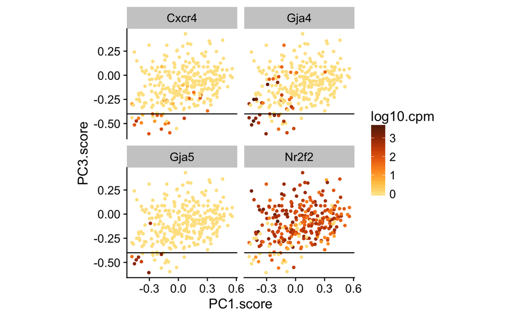

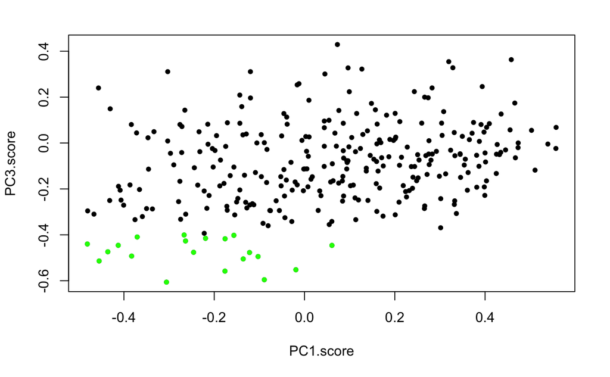

```r
cutoff <- -.4
plt=ggplot(dt.pca.2, aes(PC1.score, PC3.score, color = log10.cpm)) + geom_point(size=1) +
  scale_color_gradientn(colours=brewer.pal(9,'YlOrBr')[3:9]) +
  facet_wrap(~gene) + coord_fixed() +
  geom_hline(yintercept = cutoff)
plt
save_plot('all_r7/all_r7_separation.pdf',plt,ncol=2, nrow=2, base_height = 2.5)
cells.allr7.artl = pc.scores[(PC3.score < cutoff), cell.name]
cells.allr7.rest = pc.scores[!cell.name %in% cells.allr7.artl, cell.name]
save(cells.allr7.artl, file = 'all_r7/all_r7_artl.Rdata')
write.table(cells.allr7.artl, file = 'all_r7/all_r7_artl.txt')
save(cells.allr7.rest, file = 'all_r7/all_r7_rest.RData')
write.table(cells.allr7.rest, file = 'all_r7/all_r7_rest.txt')
with(pc.scores, plot(PC1.score, PC3.score, pch = 20))

with(pc.scores[cell.name %in% cells.allr7.artl],points(PC1.score, PC3.score, col = 'green', pch = 20 ))
```

# all_r8 (define Tbx1+ population)

PC10 separates a small population of Tbx1+ cells.

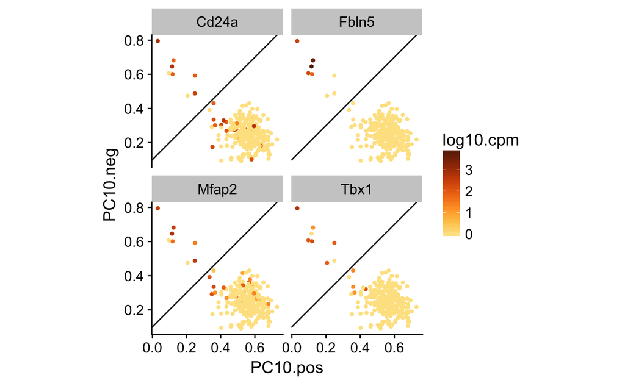

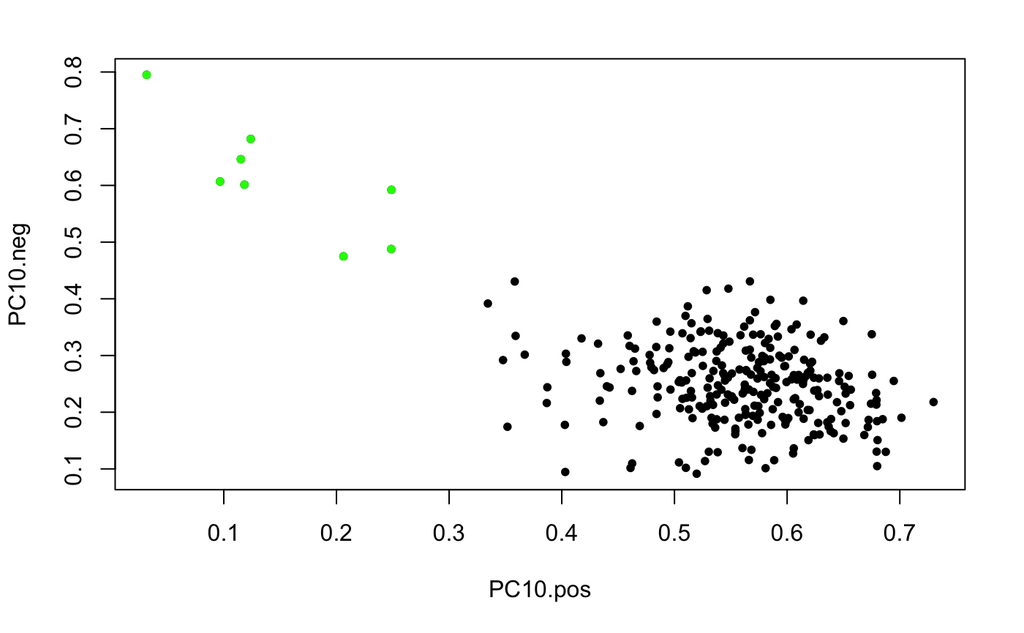

```r
pc.scores = fread(paste0(cordir, 'PC_allscores.csv'))
dt.pca.2 = merge(dt.pca[gene %in% c('Tbx1','Fbln5','Cd24a','Mfap2')],
                 pc.scores[,c('cell.name',colnames(pc.scores)[colnames(pc.scores) %like% "PC[0-9]"]), with = F],
                 by = 'cell.name')
cutoff=-.1
plt=ggplot(dt.pca.2, aes(PC10.pos, PC10.neg, color = log10.cpm)) + geom_point(size=1) +
  scale_color_gradientn(colours=brewer.pal(9,'YlOrBr')[3:9]) +
  facet_wrap(~gene) + coord_fixed() +
  geom_abline(intercept = -cutoff)
plt
save_plot('all_r8/all_r8_separation.pdf',plt,ncol=2, nrow=2, base_height = 2.5)
cells.allr8.Tbx1 = pc.scores[PC10.score < cutoff, cell.name]
cells.allr8.rest = pc.scores[!cell.name %in% cells.allr8.Tbx1, cell.name]
save(cells.allr8.Tbx1, file = 'all_r8/all_r8_Tbx1.RData')
write.table(cells.allr8.Tbx1, file = 'all_r8/all_r8_Tbx1.txt')
save(cells.allr8.rest, file = 'all_r8/all_r8_rest.RData')
write.table(cells.allr8.rest, file = 'all_r8/all_r8_rest.txt')
with(pc.scores, plot(PC10.pos, PC10.neg, pch = 20))

with(pc.scores[cell.name %in% cells.allr8.Tbx1],points(PC10.pos, PC10.neg, col = 'green', pch = 20 ))
```

# all_r9 (define tip/stalk)

PC2 separates CV Plexus cells expressing tip markers (Id2, Rgs2) and stalk markers (Apln). Separate them at the transition from Id2+ to Apln+ (tip cells are Id2+, stalk cells are Apln+)

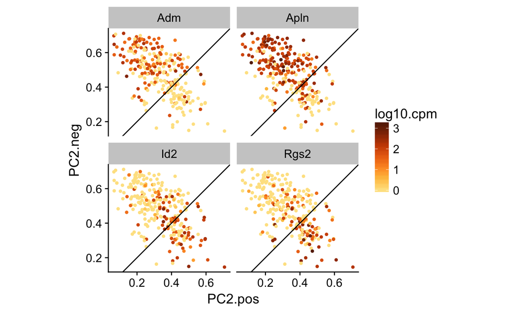

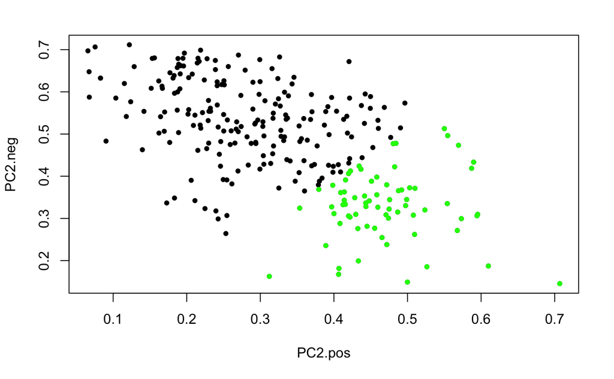

```r
cutoff=0
plt=ggplot(dt.pca.2, aes(PC2.pos, PC2.neg, color = log10.cpm)) + geom_point(size=1) +
  scale_color_gradientn(colours=brewer.pal(9,'YlOrBr')[3:9]) +
  facet_wrap(~gene) + coord_fixed() +
  geom_abline(intercept = -cutoff)
plt
save_plot(paste0(cordir,'all_r9_separation.pdf'),plt,ncol=2, nrow=2, base_height = 2.5)
cells.allr9.tip = pc.scores[PC2.score > cutoff, cell.name]
cells.allr9.stalk = pc.scores[!cell.name %in% cells.allr9.tip, cell.name]
save(cells.allr9.tip, file = paste0(cordir,'all_r9_tip.RData'))
write.table(cells.allr9.tip, file = paste0(cordir,'all_r9_tip.txt'))
save(cells.allr9.stalk, file = paste0(cordir,'all_r9_stalk.RData'))
write.table(cells.allr9.stalk, file = paste0(cordir,'all_r9_stalk.txt'))
with(pc.scores, plot(PC2.pos, PC2.neg, pch = 20))

with(pc.scores[cell.name %in% cells.allr9.tip],points(PC2.pos, PC2.neg, col = 'green', pch = 20 ))
```

# SVv-SVc (define SVc)

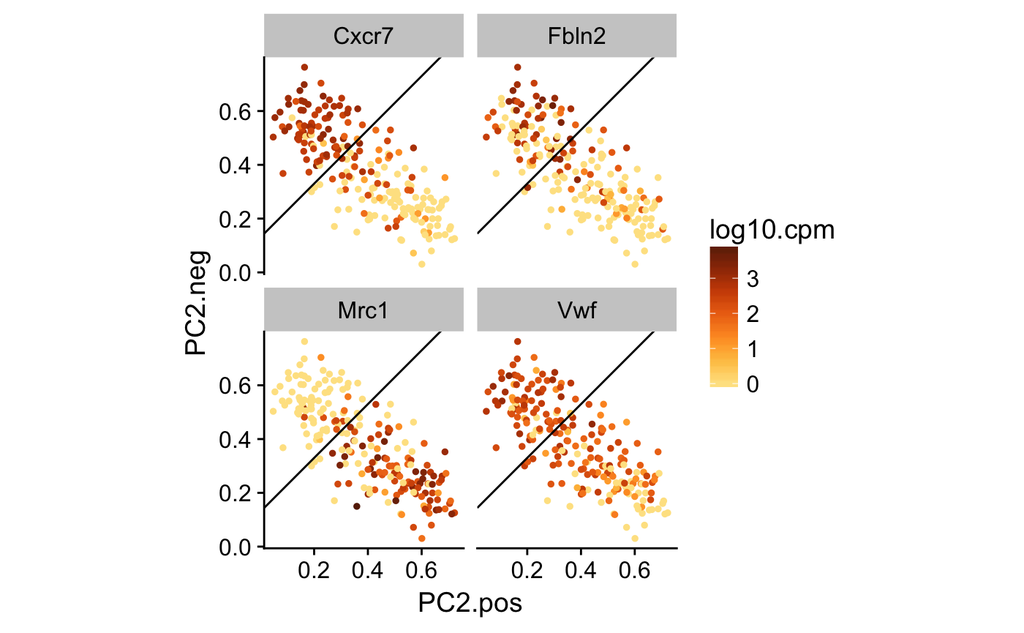

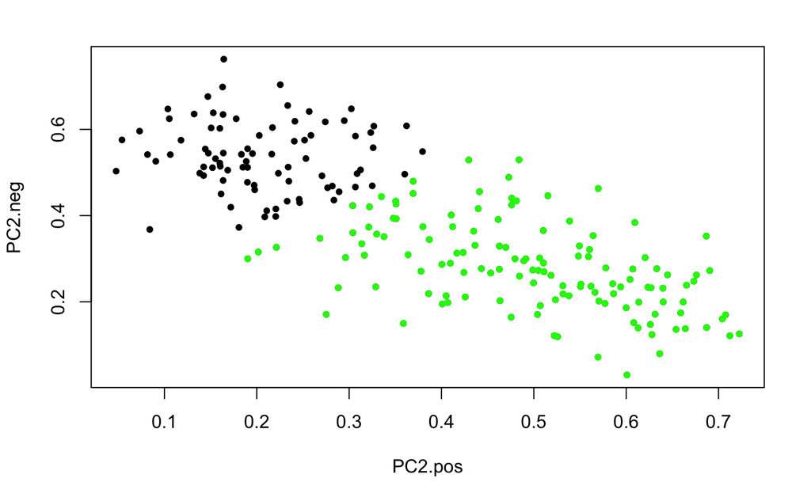

```r
pc.scores = fread(paste0(cordir, 'PC_allscores.csv'))
dt.pca.2 = merge(dt.pca[gene %in% c('Fbln2','Cxcr7','Vwf','Mrc1')],
                 pc.scores[,c('cell.name',colnames(pc.scores)[colnames(pc.scores) %like% "PC[0-9]"]), with = F],
                 by = 'cell.name')
cutoff = -.13
plt=ggplot(dt.pca.2, aes(PC2.pos, PC2.neg, color = log10.cpm)) + geom_point(size=1) +
  scale_color_gradientn(colours=brewer.pal(9,'YlOrBr')[3:9]) +
  facet_wrap(~gene) + coord_fixed() +
  geom_abline(intercept = -cutoff)
plt
save_plot(paste0(cordir,'separation.pdf'),plt,ncol=2, nrow=2, base_height = 2.5)
cells.allSVv_SVc.SVc = pc.scores[PC2.score > cutoff, cell.name]
cells.allSVv_SVc.rest = pc.scores[!cell.name %in% cells.allSVv_SVc.SVc, cell.name]
save(cells.allSVv_SVc.SVc, file = paste0(cordir,'all_SVv_SVc_SVc.RData'))
write.table(cells.allSVv_SVc.SVc, file = paste0(cordir,'all_SVv_SVc_SVc.txt'))
save(cells.allSVv_SVc.rest, file = paste0(cordir,'all_SVv_SVc_rest.RData'))
write.table(cells.allSVv_SVc.rest, file = paste0(cordir,'all_SVv_SVc_rest.txt'))
with(pc.scores, plot(PC2.pos, PC2.neg, pch = 20))

with(pc.scores[cell.name %in% cells.allSVv_SVc.SVc],points(PC2.pos, PC2.neg, col = 'green', pch = 20 ))
```

# All r10

All cells minus the populations already defined: endocardial, SVc, CV Plexus, Arterial, Tbx1, Fbln5, immune, and Hbb+. PC2: strongest (most correlated) signature: Aplnr-Fst SVv-valve gradient.

PC9: Pdgfra+ cells PC10: cell cycle

```r
cordir='all_r10/'
rm(list=ls()[ls() %like% 'cells.*'])
load('all_r1/cells_hbb_hi.RData')
load("endocard_refine_r5/cells_endocardRefine.r5.v2.endocard.Rdata")
load("all_r8/all_r8_Tbx1.RData")
load("all_r9/all_r9_stalk.RData")
load("all_r9/all_r9_tip.RData")
load("SVv_SVc/all_SVv_SVc_SVc.RData")
load("all_r7/all_r7_artl.Rdata")
load("all_r4/all_r4_immune.RData")

cells.already.defined = c(cells.allr4.immune, cells.hbb.hi, cells.endocardRefine.r5.v2.endocard, cells.allSVv_SVc.SVc, cells.allr9.tip, cells.allr9.stalk, cells.allr8.Tbx1, cells.allr7.artl)


dt.pca = dt.fv1_NS.good[!cell.name %in% c(cells.already.defined)][!gene %in% genes.cc]
setkey(dt.pca)
cell.info = copy(fv1_NS.cell.info)
cell.info[, experiment := sort.plate]
cell.info[, experiment_color := sort.plate_color]
cell.info[, sum.counts := num.mouse.reads]


# n.pcs = 10
# pca.d1 <- dimplots.pca.lowMem(dt.pca,cell.info,cordir,suffix='',max.genes = 30,ncp=n.pcs,
#                               min.cells.detect=1,n.cores = 8, min.numgenes = 3500)
# plot.ggpairs.wExptCols(cell.info,dir=cordir,suffix='',num.pcs = n.pcs,height=25,width=25,sigType = 'Sig',annot.expt = F)
# plot.ggpairs.wExptCols(cell.info,dir=cordir,suffix='',num.pcs = n.pcs,height=25,width=25,sigType = 'PC',annot.expt = F)
#
# make.facet.biplots(dt.pca,c(paste0('PC',2),paste0('PC',9)),cordir,size=1.5, plot.pdf = T)
# make.facet.biplots(dt.pca,c(paste0('PC',2),paste0('PC',5)),cordir,size=1.5, plot.pdf = T)
# # make.facet.biplots(dt.pca,c(paste0('PC',2),paste0('PC',3)),cordir,size=1.5, plot.pdf = T)
# # make.facet.biplots(dt.pca,c(paste0('PC',2),paste0('PC',9)),cordir,size=1.5, plot.pdf = T)
#
# registerDoMC(detectCores())
# foreach(i=1:n.pcs) %dopar% {
#   make.facet.biplots(dt.pca,c(paste0('PC',i),paste0('PC',i)),cordir,ax.suf = c('.pos','.neg'),size=1.5,
#                      height = 12,width = 15,num.genes = 15, plot.pdf = T, suffix = '')
# }
#
pc.scores = fread(paste0(cordir, 'PC_allscores.csv'))
dt.pca.2 = merge(dt.pca[gene %in% c('Aplnr','Fbln2','Fst','Corin')],
                 pc.scores[,c('cell.name',colnames(pc.scores)[colnames(pc.scores) %like% "PC[0-9]"]), with = F],
                 by = 'cell.name')

plt=ggplot(dt.pca.2, aes(PC2.score, PC9.score, color = log10.cpm)) + geom_point(size=1) +
  scale_color_gradientn(colours=brewer.pal(9,'YlOrBr')[3:9]) +
  facet_wrap(~gene) + coord_fixed() +
  geom_vline(xintercept = -.2)
plt
save_plot(paste0(cordir,'separation.pdf'),plt,ncol=2, nrow=2, base_height = 2.5)

cells.allr10.aplnr = pc.scores[PC2.score < -.2, cell.name]
cells.allr10.rest = pc.scores[!cell.name %in% cells.allr10.aplnr, cell.name]

save(cells.allr10.aplnr, file = paste0(cordir,'all_r10_SVv.RData'))
write.table(cells.allr10.aplnr, file = paste0(cordir,'all_r10_SVv.txt'))
save(cells.allr10.rest, file = paste0(cordir,'all_r10_rest.RData'))
write.table(cells.allr10.rest, file = paste0(cordir,'all_r10_rest.txt'))

pdf(paste0(cordir,'all_r10_separation_verification.pdf'), height = 4, width = 4)
with(pc.scores, plot(PC2.score, PC9.score, pch = 20))
with(pc.scores[cell.name %in% cells.allr10.aplnr],points(PC2.score, PC9.score, col = 'green', pch = 20 ))
dev.off()
```

# All r11 (Define mesenchymal 1/2)

All cells minus endocardial, SVc, CV Plexus, Arterial, Tbx1, Fbln5, immune, RBC, most of SVv (left: mesenchyme and valve)

```r
cordir='all_r11/'
rm(list=ls()[ls() %like% 'cells.*'])
load('all_r10/all_r10_rest.RData')

dt.pca = dt.fv1_NS.good[cell.name %in% c(cells.allr10.rest)][!gene %in% genes.cc]
setkey(dt.pca)
cell.info = copy(fv1_NS.cell.info)
cell.info[, experiment := sort.plate]
cell.info[, experiment_color := sort.plate_color]
cell.info[, sum.counts := num.mouse.reads]


# n.pcs = 10
# pca.d1 <- dimplots.pca.lowMem(dt.pca,cell.info,cordir,suffix='',max.genes = 30,ncp=n.pcs,
#                               min.cells.detect=1,n.cores = 8, min.numgenes = 3500)
# plot.ggpairs.wExptCols(cell.info,dir=cordir,suffix='',num.pcs = n.pcs,height=25,width=25,sigType = 'Sig',annot.expt = F)
# plot.ggpairs.wExptCols(cell.info,dir=cordir,suffix='',num.pcs = n.pcs,height=25,width=25,sigType = 'PC',annot.expt = F)
#
# make.facet.biplots(dt.pca,c(paste0('PC',2),paste0('PC',4)),cordir,size=1.5, plot.pdf = T)
# # make.facet.biplots(dt.pca,c(paste0('PC',2),paste0('PC',5)),cordir,size=1.5, plot.pdf = T)
# # make.facet.biplots(dt.pca,c(paste0('PC',2),paste0('PC',3)),cordir,size=1.5, plot.pdf = T)
# # make.facet.biplots(dt.pca,c(paste0('PC',2),paste0('PC',9)),cordir,size=1.5, plot.pdf = T)
#
# registerDoMC(detectCores())
# foreach(i=1:n.pcs) %dopar% {
#   make.facet.biplots(dt.pca,c(paste0('PC',i),paste0('PC',i)),cordir,ax.suf = c('.pos','.neg'),size=1.5,
#                      height = 12,width = 15,num.genes = 15, plot.pdf = T, suffix = '')
# }

pc.scores = fread(paste0(cordir, 'PC_allscores.csv'))
dt.pca.2 = merge(dt.pca[gene %in% c('Postn','Pdgfra','Nrp1','Cfh', 'Irx5','Wnt2')],
                 pc.scores[,c('cell.name',colnames(pc.scores)[colnames(pc.scores) %like% "PC[0-9]"]), with = F],
                 by = 'cell.name')

plt=ggplot(dt.pca.2, aes(PC2.score, PC3.score, color = log10.cpm)) + geom_point(size=1) +
  scale_color_gradientn(colours=brewer.pal(9,'YlOrBr')[3:9]) +
  facet_wrap(~gene) + coord_fixed() +
  geom_abline(slope=-.5, intercept = -.2) +
  geom_abline(slope=2, intercept = 0)
plt
save_plot(paste0(cordir,'separation.pdf'),plt,ncol=3, nrow=2, base_height = 2.5)
#
cells.allr11.Mes1 = pc.scores[(PC3.score < -.5*PC2.score -.2) & (PC3.score < 2*PC2.score), cell.name]
cells.allr11.Mes2 = pc.scores[(PC3.score < -.5*PC2.score -.2) & (PC3.score >= 2*PC2.score), cell.name]
cells.allr11.rest = pc.scores[!cell.name %in% c(cells.allr11.Mes1, cells.allr11.Mes2), cell.name]

save(cells.allr11.Mes1, file = paste0(cordir,'all_r11_Mes1.RData'))
write.table(cells.allr11.Mes1, file = paste0(cordir,'all_r11_Mes1.txt'))
save(cells.allr11.Mes2, file = paste0(cordir,'all_r11_Mes2.RData'))
write.table(cells.allr11.Mes2, file = paste0(cordir,'all_r11_Mes2.txt'))

save(cells.allr11.rest, file = paste0(cordir,'all_r11_rest.RData'))
write.table(cells.allr11.rest, file = paste0(cordir,'all_r11_rest.txt'))

pdf(paste0(cordir,'all_r11_separation_verification.pdf'), height = 4, width = 4)
with(pc.scores, plot(PC2.score, PC3.score, pch = 20))
with(pc.scores[cell.name %in% cells.allr11.Mes1],points(PC2.score, PC3.score, col = 'green', pch = 20 ))
with(pc.scores[cell.name %in% cells.allr11.Mes2],points(PC2.score, PC3.score, col = 'red', pch = 20 ))
dev.off()
```

# all_r12 (define Col1a1 cells)

All cells minus endocardial, SVc, CV Plexus, Arterial, Tbx1, Fbln5, immune, RBC, and Mesenchymal (Pdgfra)

```r
cordir='all_r12/'
rm(list=ls()[ls() %like% 'cells.*'])
load('all_r11/all_r11_rest.RData')
load('all_r10/all_r10_SVv.RData')

dt.pca = dt.fv1_NS.good[cell.name %in% c(cells.allr11.rest, cells.allr10.aplnr)][!gene %in% genes.cc]
setkey(dt.pca)
cell.info = copy(fv1_NS.cell.info)
cell.info[, experiment := sort.plate]
cell.info[, experiment_color := sort.plate_color]
cell.info[, sum.counts := num.mouse.reads]


# n.pcs = 10
# pca.d1 <- dimplots.pca.lowMem(dt.pca,cell.info,cordir,suffix='',max.genes = 30,ncp=n.pcs,
#                               min.cells.detect=1,n.cores = 8, min.numgenes = 3500)
# plot.ggpairs.wExptCols(cell.info,dir=cordir,suffix='',num.pcs = n.pcs,height=25,width=25,sigType = 'Sig',annot.expt = F)
# plot.ggpairs.wExptCols(cell.info,dir=cordir,suffix='',num.pcs = n.pcs,height=25,width=25,sigType = 'PC',annot.expt = F)
#
# make.facet.biplots(dt.pca,c(paste0('PC',2),paste0('PC',3)),cordir,size=1.5, plot.pdf = T)
# # make.facet.biplots(dt.pca,c(paste0('PC',2),paste0('PC',5)),cordir,size=1.5, plot.pdf = T)
# # make.facet.biplots(dt.pca,c(paste0('PC',2),paste0('PC',3)),cordir,size=1.5, plot.pdf = T)
# # make.facet.biplots(dt.pca,c(paste0('PC',2),paste0('PC',9)),cordir,size=1.5, plot.pdf = T)
#
# registerDoMC(detectCores())
# foreach(i=c(9, 10)) %do% {
#   make.facet.biplots(dt.pca,c(paste0('PC',i),paste0('PC',i)),cordir,ax.suf = c('.pos','.neg'),size=1.5,
#                      height = 12,width = 15,num.genes = 15, plot.pdf = T, suffix = '')
# }
#
pc.scores = fread(paste0(cordir, 'PC_allscores.csv'))
dt.pca.2 = merge(dt.pca[gene %in% c('Col1a1','Col1a2','Cd93','Ppa2b')],
                 pc.scores[,c('cell.name',colnames(pc.scores)[colnames(pc.scores) %like% "PC[0-9]"]), with = F],
                 by = 'cell.name')

plt=ggplot(dt.pca.2, aes(PC9.pos, PC9.neg, color = log10.cpm)) + geom_point(size=1) +
  scale_color_gradientn(colours=brewer.pal(9,'YlOrBr')[3:9]) +
  facet_wrap(~gene) + coord_fixed() +
  geom_abline(intercept = .4)
plt
save_plot(paste0(cordir,'separation.pdf'),plt,ncol=2, nrow=2, base_height = 2.5)
#
cells.allr12.col1a1 = pc.scores[PC9.score < -.4, cell.name]
cells.allr12.rest = pc.scores[!cell.name %in% cells.allr12.col1a1, cell.name]

save(cells.allr12.col1a1, file = paste0(cordir,'all_r12_col1a1.RData'))
write.table(cells.allr12.col1a1, file = paste0(cordir,'all_r12_col1a1.txt'))
save(cells.allr12.rest, file = paste0(cordir,'all_r12_rest.RData'))
write.table(cells.allr12.rest, file = paste0(cordir,'all_r12_rest.txt'))

pdf(paste0(cordir,'all_r12_separation_verification.pdf'), height = 4, width = 4)
with(pc.scores, plot(PC9.pos, PC9.neg, pch = 20))
with(pc.scores[cell.name %in% cells.allr12.col1a1],points(PC9.pos, PC9.neg, col = 'green', pch = 20 ))
dev.off()
```

# All r13 (define Foxf1a)

PC1 and PC10 are cell cycle PC2 and PC3 are strong phenotype signatures

```r
cordir='all_r13/'
rm(list=ls()[ls() %like% 'cells.*'])
load('all_r12/all_r12_rest.RData')

dt.pca = dt.fv1_NS.good[cell.name %in% c(cells.allr12.rest)][!gene %in% genes.cc]
setkey(dt.pca)
cell.info = copy(fv1_NS.cell.info)
cell.info[, experiment := sort.plate]
cell.info[, experiment_color := sort.plate_color]
cell.info[, sum.counts := num.mouse.reads]


# n.pcs = 10
# pca.d1 <- dimplots.pca.lowMem(dt.pca,cell.info,cordir,suffix='',max.genes = 30,ncp=n.pcs,
#                               min.cells.detect=1,n.cores = 8, min.numgenes = 3500)
# plot.ggpairs.wExptCols(cell.info,dir=cordir,suffix='',num.pcs = n.pcs,height=25,width=25,sigType = 'Sig',annot.expt = F)
# plot.ggpairs.wExptCols(cell.info,dir=cordir,suffix='',num.pcs = n.pcs,height=25,width=25,sigType = 'PC',annot.expt = F)
#
# make.facet.biplots(dt.pca,c(paste0('PC',2),paste0('PC',4)),cordir,size=1.5, plot.pdf = T)
# make.facet.biplots(dt.pca,c(paste0('PC',2),paste0('PC',3)),cordir,size=1.5, plot.pdf = T)
# make.facet.biplots(dt.pca,c(paste0('PC',2),paste0('PC',3)),cordir,size=1.5, plot.pdf = T)
# make.facet.biplots(dt.pca,c(paste0('PC',2),paste0('PC',9)),cordir,size=1.5, plot.pdf = T)
#
# registerDoMC(detectCores())
# foreach(i=c(9)) %do% {
#   make.facet.biplots(dt.pca,c(paste0('PC',i),paste0('PC',i)),cordir,ax.suf = c('.pos','.neg'),size=1.5,
#                      height = 12,width = 15,num.genes = 20, plot.pdf = T, suffix = '')
# }
#
pc.scores = fread(paste0(cordir, 'PC_allscores.csv'))
dt.pca.2 = merge(dt.pca[gene %in% c('Foxf1a','Nrg1','Lifr','Pecam1')],
                 pc.scores,
                 by = 'cell.name')
#
plt=ggplot(dt.pca.2, aes(PC9.pos, PC9.neg, color = log10.cpm)) + geom_point(size=1) +
  scale_color_gradientn(colours=brewer.pal(9,'YlOrBr')[3:9]) +
  facet_wrap(~gene) + coord_fixed() +
  geom_abline(intercept = -.3)
plt
save_plot(paste0(cordir,'separation.pdf'),plt,ncol=2, nrow=2, base_height = 2.5)

cells.allr13.foxf1a = pc.scores[PC9.score > .3, cell.name]
cells.allr13.rest = pc.scores[!cell.name %in% cells.allr13.foxf1a, cell.name]

save(cells.allr13.foxf1a, file = paste0(cordir,'all_r13_foxf1a.RData'))
write.table(cells.allr13.foxf1a, file = paste0(cordir,'all_r13_foxf1a.txt'))
save(cells.allr13.rest, file = paste0(cordir,'all_r13_rest.RData'))
write.table(cells.allr13.rest, file = paste0(cordir,'all_r13_rest.txt'))

pdf(paste0(cordir,'all_r13_separation_verification.pdf'), height = 4, width = 4)
with(pc.scores, plot(PC9.pos, PC9.neg, pch = 20))
with(pc.scores[cell.name %in% cells.allr13.foxf1a],points(PC9.pos, PC9.neg, col = 'green', pch = 20 ))
dev.off()
```

# All r14 (Define SVv)

PC1 is highly correlated to # of genes (technical variability). PC10 are cell cycle. PC2 and PC3 are strong phenotype signatures.

Appears only remaining heterogeneity is SVv (Aplnr+) and two subgroups of Venuous valve (Wnt2+ and Igfbp5)

```r
cordir='all_r14/'
rm(list=ls()[ls() %like% 'cells.*'])
load('all_r13/all_r13_rest.RData')

dt.pca = dt.fv1_NS.good[cell.name %in% c(cells.allr13.rest)][!gene %in% genes.cc]
setkey(dt.pca)
cell.info = copy(fv1_NS.cell.info)
cell.info[, experiment := sort.plate]
cell.info[, experiment_color := sort.plate_color]
cell.info[, sum.counts := num.mouse.reads]


# n.pcs = 10
# pca.d1 <- dimplots.pca.lowMem(dt.pca,cell.info,cordir,suffix='',max.genes = 30,ncp=n.pcs,
#                               min.cells.detect=1,n.cores = 8, min.numgenes = 3500)
# plot.ggpairs.wExptCols(cell.info,dir=cordir,suffix='',num.pcs = n.pcs,height=25,width=25,sigType = 'Sig',annot.expt = F)
# plot.ggpairs.wExptCols(cell.info,dir=cordir,suffix='',num.pcs = n.pcs,height=25,width=25,sigType = 'PC',annot.expt = F)
#
# make.facet.biplots(dt.pca,c(paste0('PC',2),paste0('PC',3)),cordir,size=1.5, plot.pdf = T)
#
# registerDoMC(detectCores())
# foreach(i=c(1,2,3)) %do% {
#   make.facet.biplots(dt.pca,c(paste0('PC',i),paste0('PC',i)),cordir,ax.suf = c('.pos','.neg'),size=1.5,
#                      height = 12,width = 15,num.genes = 20, plot.pdf = T, suffix = '')
# }

pc.scores = fread(paste0(cordir, 'PC_allscores.csv'))
dt.pca.2 = merge(dt.pca[gene %in% c('Wnt2','Cfh','Corin','Fbln2')],
                 pc.scores,
                 by = 'cell.name')
#
plt=ggplot(dt.pca.2, aes(PC2.score, PC3.score, color = log10.cpm)) + geom_point(size=1) +
  scale_color_gradientn(colours=brewer.pal(9,'YlOrBr')[3:9]) +
  facet_wrap(~gene) + coord_fixed() +
  geom_abline(slope = -2, intercept = 0.35)+
    geom_abline(slope = .5, intercept = 0)

plt
save_plot(paste0(cordir,'separation.pdf'),plt,ncol=2, nrow=2, base_height = 2.5)
#

cells.allr14.VV1 = pc.scores[(PC3.score < -2*PC2.score + .35) & (PC3.score > .5*PC2.score), cell.name]
cells.allr14.VV2 = pc.scores[(PC3.score < -2*PC2.score + .35) & (PC3.score <= .5*PC2.score), cell.name]
cells.allr14.SVv = pc.scores[!cell.name %in% c(cells.allr14.VV1, cells.allr14.VV2), cell.name]


save(cells.allr14.VV1, file = paste0(cordir,'all_r14_VV1.RData'))
write.table(cells.allr14.VV1, file = paste0(cordir,'all_r14_VV1.txt'))
save(cells.allr14.VV2, file = paste0(cordir,'all_r14_VV2.RData'))
write.table(cells.allr14.VV2, file = paste0(cordir,'all_r14_VV2.txt'))

save(cells.allr14.SVv, file = paste0(cordir,'all_r14_SVv.RData'))
write.table(cells.allr14.SVv, file = paste0(cordir,'all_r14_SVv.txt'))

pdf(paste0(cordir,'all_r14_separation_verification.pdf'), height = 4, width = 4)
with(pc.scores, plot(PC2.score, PC3.score,pch = 20))
with(pc.scores[cell.name %in% cells.allr14.VV1],points(PC2.score, PC3.score, col = 'green', pch = 20 ))
with(pc.scores[cell.name %in% cells.allr14.VV2],points(PC2.score, PC3.score, col = 'red', pch = 20 ))
dev.off()
```